# Data Exploration and Deterministic Functions

Analysis of Environmental Data

Adrienne Dunk

# Q1: Terrain Histograms

### Create histograms for the three terrain variables: Elevation, Slope, and Aspect and plot them in a single figure.

```r
getwd() #check working directory
```

```
## [1] "C:/Users/adrienne.dunk/Documents/environmental_data/assignments"
```

```r
require(here) #load here into session
here() #check directory
```

```
## [1] "C:/Users/adrienne.dunk/Documents/environmental_data"
```

```r
dat_habitat <- read.csv(here("data", "hab.sta.csv"))
class(dat_habitat) #check class
```

```
## [1] "data.frame"
```

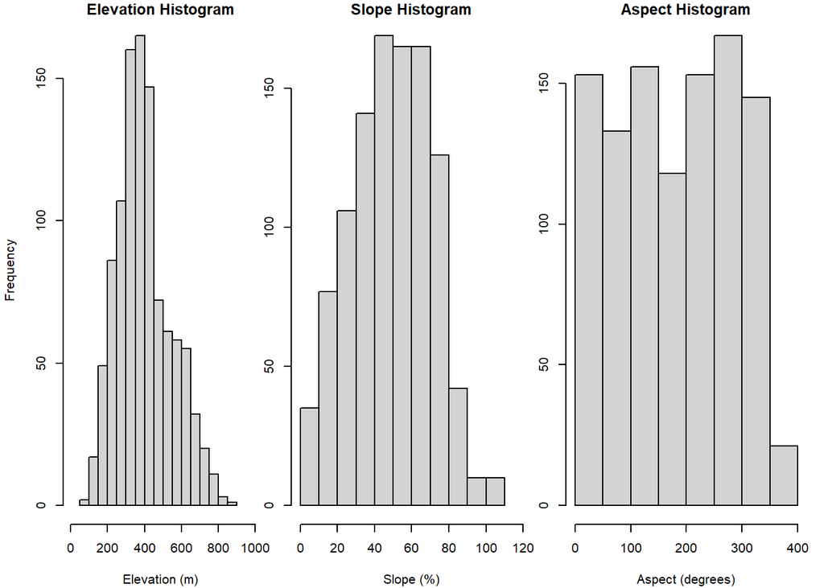

```r
elev_xrange <- c(0, max(dat_habitat$elev)+100)
slope_xrange <- c(0, max(dat_habitat$slope)+10)
aspect_xrange <- c(min(dat_habitat$aspect), max(dat_habitat$aspect)+40)


par(mfrow = c(1,3), mar = c(4.1, 4.1, 1.1, 1.1))
hist(dat_habitat$elev, main = "Elevation Histogram", xlab = "Elevation (m)", xlim = elev_xrange)

par(mar = c(4.1, 1.1, 1.1, 1.1))
hist(dat_habitat$slope, main = "Slope Histogram", xlab = "Slope (%)", xlim = slope_xrange, ylab = NULL)
hist(dat_habitat$aspect, main = "Aspect Histogram", xlab = "Aspect (degrees)", xlim = aspect_xrange, ylab = NULL, breaks = 9)
```

# Q2: Elevation Histogram Interpretation

### Interpret the shape of the elevation histogram in non-technical language. Disucss the distribution of the sampling site elevations.

# Q3: Slope Units

### What are the units of slope in this data set (Hint: Check the metadata)

Slope is measured in percent slope (%) meausred as a number between 0 and 110%.

# Q4: Slope Histogram Interpretation

### Consider the distribution of slopes at the bird census sample sites. Interpret the shape of the slope histogram in non-technical lanauge. Discuss the distribution of the slopes.

The slope data indicates that the slopes measured are not normally distibuted, meaning that they are not symmetrical around the mean. The data show that more sites 40-80% slope range were measured than in either the shallower or steeper ranges. There is a mixture of shallow and steep slopes, but there are far fewer steep slope sites than mid- or low-slope.

# Q5: Aspect

### Define aspect, using the units from this dataset.

Aspect was measured in this dataset as degrees measured in numbers ranging from 0 to 360. Likely, 0 and 360 degrees are both north, with 90 representing east, 180 representing west, and 270 representing west.

# Q6: Aspect Histogram Interpretation

### Consider the distribution of the aspect histogram at bird census sample sites. Interpret the shape of the aspect data in non-technical language. Discuss the distribution of the aspects.

The aspect histogram indicates that the sample aspects are relatively evenly represented with the exception of 360 degrees, though this may be misleading as 0 and 360 degrees are the same, the distribution may be skewed by a preference for representing north as 0 instead of 360.There appear to be the most west facing sites, with the fewest south facing sites.

# Q7: Terrain/Basal Area Linear Models

### Create scatterplots of total basal area and each terrain variable. Fit a linear function to each terrain variable.

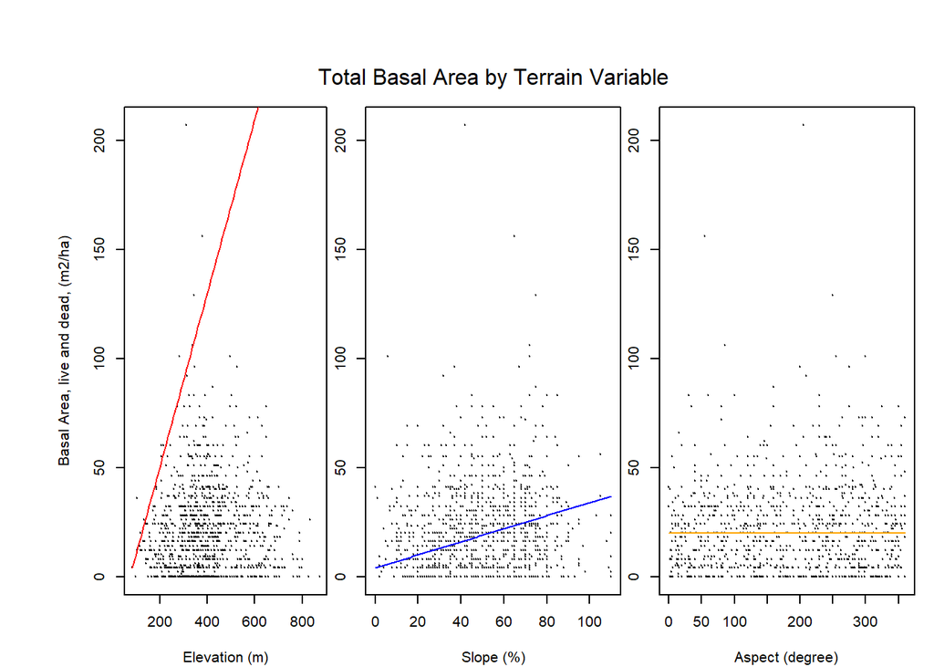

```r
line_point_slope = function(x, x1, y1, slope){
  get_y_intercept = function(x1, y1, slope)
    return(-(x1 * slope)+y1)

  linear =
    function(x, yint, slope)
      return(yint + x* slope)

  return(linear(x, get_y_intercept(x1,y1,slope), slope))
}

par(mfrow = c(1,3), mar = c(4.1, 4.1, 1.1, 1.1), oma = c(0, 3, 5, 0))
plot(
  x = dat_habitat$elev,
  y = dat_habitat$ba.tot,
  ylab = "Basal Area, live and dead, (m2/ha)",
  xlab = "Elevation (m)", pch = 20, cex = .2
  )
curve(line_point_slope(x, x1 = 200, y1 = 50, slope = .4), add = TRUE, col = "red")

par(mar = c(4.1, 1.1, 1.1, 1.1))

plot(
  x = dat_habitat$slope,
  y = dat_habitat$ba.tot,
  ylab = NULL,
  xlab = "Slope (%)", pch = 20, cex = .2
  )
curve(line_point_slope(x, x1 = 70, y1 = 25, slope = 0.3), add = TRUE, col = "blue")

plot(
  x = dat_habitat$aspect,
  y = dat_habitat$ba.tot,
  ylab = NULL,
  xlab = "Aspect (degree)", pch = 20, cex = .2
  )
curve(line_point_slope(x, x1 = 0, y1 = 20, slope = 0), add = TRUE, col = "orange")

mtext("Total Basal Area by Terrain Variable", outer = T, side = 3)
```

# Q8: Terrain/Basal Model Interpretation

### For each terrain variable, describe the relationship and model fit observed.

*Elevation:* The highest rates of basal area cover appear to correspond to the mid-range of the elevation. The total basal cover decreases in both the low- and high-elevation ranges. This relationship isn’t linear, so the linear model that I fit does a poor job describing how the basal area decreases as elevation increases above approximately 375 meters.

*Slope:* The basal area appears to increase linearly with slope, though the data spread also increases with slope creating a lot of noise. The fit model does an adequate job describing the relationship.

*Aspect:* The basal area does not appear to have a relationship with aspect. As such, the linear model has a zero-slope. The linear model provides an adquate description of the data but does not provide insight.